# Celltype Co-ocurance

**Are myeloid cells migrating closer to the epithelia in crohn’s disease?**

We can use spicyR to test if there is a change in the relative closeness of different celltypes (e.g. myeloid and epithelia) across different condition.

See: [spicyR vignette](https://www.bioconductor.org/packages/release/bioc/vignettes/spicyR/inst/doc/spicyR.html#41_Test_for_change_in_localisation_for_a_specific_pair_of_cells)

# Build the input table for spicyR

SpicyR can work with a SFE object, but not in this specific case (It lacks image data, and some coordinates are negative). So instead, we will build a table of the relevant input data.

For every cell, it requires the following

- Cell type
- X and Y coordinates
- Sample ID
- Sample condition
- FOV (optional)

The centroid coordinates of each cell are available with the spatialCoords function

```r
head(spatialCoords(sfe))
```

```
##        CenterX_global_px CenterY_global_px
## 1000_1        20114.5556          172987.6
## 1000_2        16544.1111          172548.4
## 1000_4          687.8889          169392.8
## 1001_1        18325.5556          173004.6
## 1001_2        17019.1111          172531.4
## 1001_3        10338.0000          170686.6
```

Everything else we need is stored in the ColData(). We can join those two tables together, and then rename some columns according to what spicyR expects.

```r
#epi => myeloid
spicy_cell_info <- as.data.frame(colData(sfe))[,c('cell', 'tissue_sample',  'celltype_subset', 'group', 'fov_name') ]
spicy_cell_info <- cbind(spicy_cell_info, spatialCoords(sfe))
spicy_cell_info <- spicy_cell_info %>%
  dplyr::rename(
    imageID = fov_name, #there are 4 fovs per tissue sample. In xenium data, that would be one per slide. And in other experiments, many samples per image.
    x=CenterX_global_px,
    y=CenterY_global_px
  )
spicy_cell_info$imageID <- droplevels(spicy_cell_info$imageID)
```

Offset any negative X/Y coordinates to positive. The absolute positions don’t matter.

```r
# remove negative values - not supported by spicyR
# Else yields error: Error in owinInternalRect(xrange, yrange, ..., unitname = unitname): xrange should be a vector of length 2 giving (xmin, xmax)
min_x <- min(spicy_cell_info$x)
min_y <- min(spicy_cell_info$y)
if (min_x < 0) {spicy_cell_info$x = spicy_cell_info$x + -(min_x) + 1 }
if (min_y < 0) {spicy_cell_info$y = spicy_cell_info$y + -(min_y) + 1 }
```

## Test proximity of myeloid cells to epithelia

```r
spicy_res <- spicy(
  cells     = spicy_cell_info ,
  subject   = 'tissue_sample',
  cellType  = 'celltype_subset',
  sigma     = 50, # tissue is not homogeneous see: https://www.bioconductor.org/packages/release/workflows/vignettes/spicyWorkflow/inst/doc/spicyWorkflow.html#14_spicyR:_Test_spatial_relationships
  condition = "group",
  from      = "epi",
  to        = "myeloids"
)
```

```
## Skipping argument checks as `getPairwise()` is being called within `spicy()`
```

NB: Garrido-Trigo et al did a detailed exploration of localisation of macrophage and neutrophil subtypes in their data. We are testing a toy subset with some very broad celltypes!

```r
topPairs(spicy_res)
```

|  | intercept | coefficient | p.value | adj.pvalue | from | to |
| --- | --- | --- | --- | --- | --- | --- |
| epi__myeloids | -20.06387 | 7.784416 | 0.5191544 | 0.5191544 | epi | myeloids |

We can plot the ‘L-function’ between these groups per condition. There is an L value for each sample, which represents the ‘closeness’ of the celltype pair in that sample. Higher values indicates co-location.

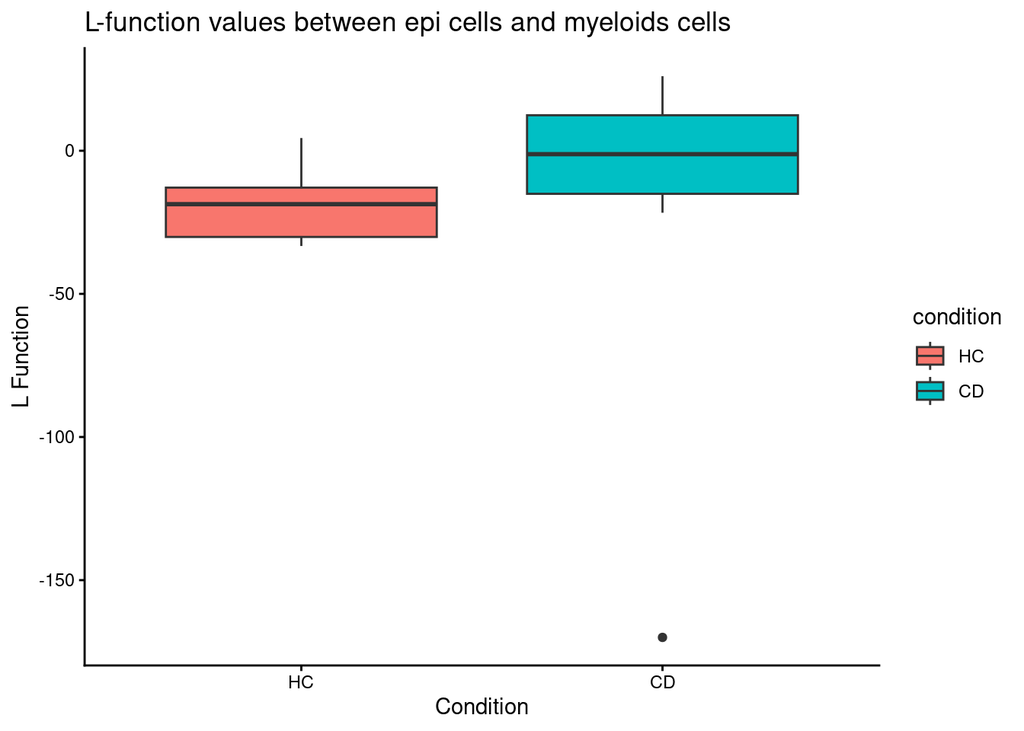

```r
spicyBoxPlot(spicy_res,
             from = "epi",
             to = "myeloids")
```

## Tests for changes across all celltypes

If we omit the pair of celltypes - all combinations will be tested.

```r
spicy_res <- spicy(
  cells     = spicy_cell_info ,
  subject   = 'tissue_sample',
  cellType  = 'celltype_subset',
  sigma     = 50, # tissue is not homogeneous see: https://www.bioconductor.org/packages/release/workflows/vignettes/spicyWorkflow/inst/doc/spicyWorkflow.html#14_spicyR:_Test_spatial_relationships
  condition = "group"
)
```

```
## Skipping argument checks as `getPairwise()` is being called within `spicy()`
```

And there is a very nice visualisation. The size of the circle scales with significant, and the colour indicates the magnitude of the ‘L’ Value.

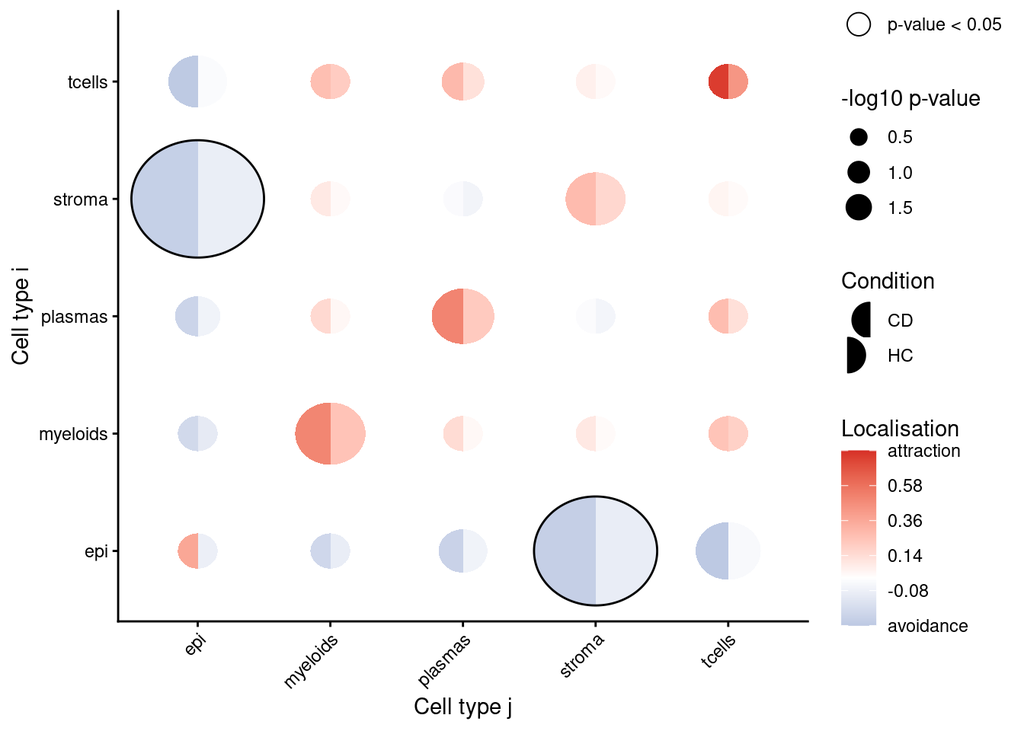

```r
signifPlot(spicy_res)
```

We should interpret this carefully (especially for such a small dataset) - is it actually interesting biology?

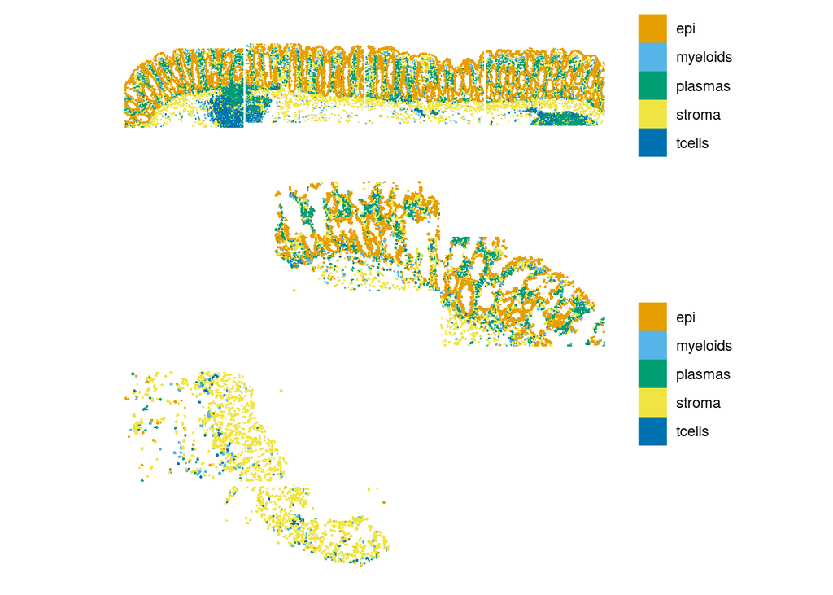

```r
p1 <- plotSpatialFeature(sfe.sample.HC, "celltype_subset",colGeometryName = "cellSeg") +
  theme(legend.title=element_blank()) +
  ggtitle(sample)

p2 <- plotSpatialFeature(sfe.sample.CD,  "celltype_subset", colGeometryName = "cellSeg") +
  theme(legend.title=element_blank()) +
  ggtitle(sample)

p1 / p2
```